# Week 4 — Comparing two groups

This week answers one question in three forms: **do two groups differ?**

The form depends on what kind of variable you are comparing.

| Outcome | Grouping variable | Test | Effect size |
| --- | --- | --- | --- |
| Continuous, approximately normal | Two categories | Independent-samples *t*-test | Cohen's *d* |
| Continuous, not normal (or ordinal) | Two categories | Mann–Whitney *U* | Rank-biserial *r* |
| Categorical | Categorical | Chi-square of independence | Cramér's *V* (φ for 2×2) |

Every analysis follows the same six steps, and you will use them for the rest of the module:

1. **State** the hypothesis pair.
2. **Inspect** the variables.
3. **Check** the assumptions and decide which test to use.
4. **Run** the test.
5. **Report** the result with an effect size.
6. **Conclude** about the hypothesis.

```python
import math9102 as m9
import numpy as np
from scipy import stats

m9.use_house_style()
```

## Part 1 — A continuous outcome across two groups

We use the wellbeing survey: 439 respondents from Melbourne, measured on validated scales for stress, optimism, control and self-esteem.

```python
survey = m9.load_survey()
survey.shape
```

```
(439, 134)
```

### Step 1: State the hypothesis

> **H₀:** There is no difference in perceived stress between respondents who have children and respondents who do not.

> **H₁:** There is a difference in perceived stress between respondents who have children and respondents who do not.

The outcome is `tpstress`, the total score on the Perceived Stress Scale. The grouping variable is `child`.

### Step 2: Inspect the variables

Start with the grouping variable. How many are in each group, and is anything missing?

```python
m9.frequency(survey, "child")
```

| child | count | percent | valid_percent |
| --- | --- | --- | --- |
| NO | 253 | 57.63 | 57.76 |
| YES | 185 | 42.14 | 42.24 |
| NaN | 1 | 0.23 | NaN |

Now the outcome, split by group. Always look at the group sizes and the spread, not just the means.

```python
m9.describe_by(survey, "tpstress", "child")
```

| child | n | missing | mean | sd | se | median | iqr | min | max | skew | kurtosis |
| --- | --- | --- | --- | --- | --- | --- | --- | --- | --- | --- | --- |
| NO | 249.0 | 4.0 | 27.036 | 6.134 | 0.389 | 27.0 | 8.0 | 12.0 | 46.0 | 0.180 | 0.173 |
| YES | 183.0 | 2.0 | 26.339 | 5.425 | 0.401 | 26.0 | 7.5 | 13.0 | 42.0 | 0.303 | 0.131 |

Before going further, check what a complete-case analysis would cost you. Do this on **the variables you are actually modelling** — not on the whole dataframe.

```python
missing = m9.missingness(survey, ["tpstress", "child"])
print(missing.attrs["summary"])
missing
```

```
Listwise deletion across these 2 column(s) keeps 432 of 439 rows (loses 7, 1.6%).
```

|  | column | missing | percent |
| --- | --- | --- | --- |
| 0 | tpstress | 6 | 1.37 |
| 1 | child | 1 | 0.23 |

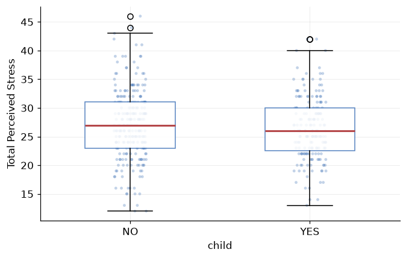

```python
m9.grouped_box(survey, "tpstress", "child", ylabel="Total Perceived Stress");
```

### Step 3: Check the assumptions

The *t*-test assumes the outcome is approximately normally distributed **within each group**. It is a common mistake to check the pooled distribution instead — that mixes the groups together and can look non-normal simply because the group means differ.

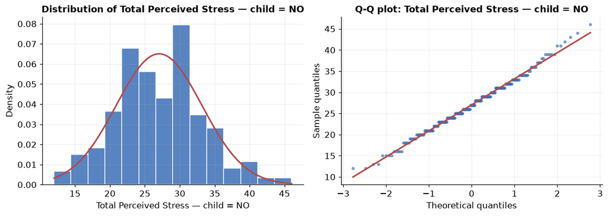

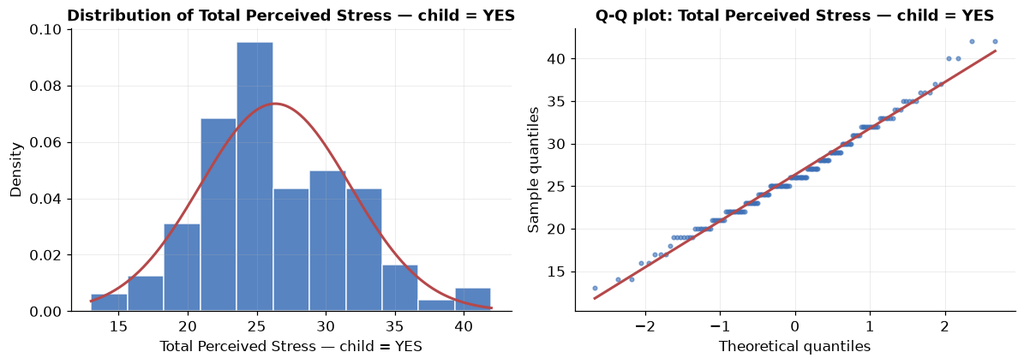

```python
for level in ["NO", "YES"]:
    group = survey.loc[survey.child == level, "tpstress"]
    m9.normality_panel(group, label=f"Total Perceived Stress — child = {level}")
```

```python
m9.report_normality(survey[survey.child == "NO"], "tpstress",
                    "Total Perceived Stress (no children)")
```

Total Perceived Stress (no children) was assessed for normality using the histogram and Q-Q plot above, supported by shape statistics (*N* = 249, *M* = 27.04, *SD* = 6.13). Skewness was 0.18 (standardised 1.16) and kurtosis 0.17 (standardised 0.56). At this sample size the standardised ratios are highly sensitive, so they are reported as descriptions of shape rather than as a pass/fail test. 0.0% of standardised scores fell beyond ±3.29, against about 0.1% expected under normality.

```python
m9.report_normality(survey[survey.child == "YES"], "tpstress",
                    "Total Perceived Stress (children)")
```

Total Perceived Stress (children) was assessed for normality using the histogram and Q-Q plot above, supported by shape statistics (*N* = 183, *M* = 26.34, *SD* = 5.43). Skewness was 0.30 (standardised 1.68) and kurtosis 0.13 (standardised 0.37). The sample is small enough that these ratios have limited power, so the visual evidence carries most of the weight. 0.0% of standardised scores fell beyond ±3.29, against about 0.1% expected under normality.

Note what the sample size does to the standardised ratios. With several hundred observations they will flag departures far too small to matter. **The plots decide the question**; the numbers describe the shape.

#### What about equal variances?

You will meet analyses that run Levene's test and then switch between a "pooled" and a "separate variances" *t*-test depending on the result. **We do not do that.** Choosing your test based on the outcome of another test distorts the error rate of the one that matters, and the decision rule is fragile — a p-value of .049 and one of .051 lead to different analyses.

Instead we always use **Welch's *t*-test**, which does not assume equal variances and costs almost nothing when they happen to be equal. Levene's test is still worth *looking* at, as a description of the data:

```python
no = survey.loc[(survey.child == "NO") & survey.tpstress.notna(), "tpstress"]
yes = survey.loc[(survey.child == "YES") & survey.tpstress.notna(), "tpstress"]

levene = stats.levene(no, yes, center="median")
print(f"Levene's test:  F = {levene.statistic:.4f},  p = {levene.pvalue:.4f}")
print(f"SD (no children)  = {no.std(ddof=1):.3f}")
print(f"SD (children)     = {yes.std(ddof=1):.3f}")
```

```
Levene's test:  F = 3.1842,  p = 0.0751
SD (no children)  = 6.134
SD (children)     = 5.425
```

### Step 4: Run the test

```python
result = stats.ttest_ind(no, yes, equal_var=False)   # Welch
result
```

```
TtestResult(statistic=np.float64(1.2485692827193056), pvalue=np.float64(0.21252573001355524), df=np.float64(415.48104871633063))
```

For comparison, the pooled-variance version — the one a Levene-gated procedure would select:

```python
pooled = stats.ttest_ind(no, yes, equal_var=True)
print(f"Welch : t = {result.statistic:.4f}, df = {result.df:.1f}, p = {result.pvalue:.4f}")
print(f"Pooled: t = {pooled.statistic:.4f}, df = {pooled.df:.0f}, p = {pooled.pvalue:.4f}")
```

```
Welch : t = 1.2486, df = 415.5, p = 0.2125
Pooled: t = 1.2254, df = 430, p = 0.2211
```

They agree here. That is the usual case, and it is why defaulting to Welch is safe.

### Step 5: Effect size

A p-value tells you whether a difference is detectable. It does not tell you whether it is **large enough to care about**. Always report an effect size.

Cohen's *d* expresses the difference in standard deviations:

```python
d = m9.cohens_d(no, yes)
print(f"Cohen's d = {d:.3f}  ({m9.interpret(d, 'd')})")
```

```
Cohen's d = 0.119  (negligible)
```

You may see the shortcut *d* = 2*t*/√df in textbooks. It assumes the two groups are the **same size**, so treat it as an approximation:

```python
approx = 2 * pooled.statistic / np.sqrt(len(no) + len(yes) - 2)
exact = pooled.statistic * np.sqrt(1 / len(no) + 1 / len(yes))
print(f"exact       : {exact:.4f}")
print(f"2t/sqrt(df) : {approx:.4f}   (n = {len(no)} vs {len(yes)})")
```

```
exact       : 0.1193
2t/sqrt(df) : 0.1182   (n = 249 vs 183)
```

### Step 6: Report and conclude

```python
m9.report_ttest(
    survey, "tpstress", "child", result,
    outcome_label="Total Perceived Stress",
    group_labels={"NO": "respondents without children",
                  "YES": "respondents with children"},
)
```

Welch's independent-samples *t*-test was conducted to compare Total Perceived Stress between respondents without children (*n* = 249, *M* = 27.04, *SD* = 6.13) and respondents with children (*n* = 183, *M* = 26.34, *SD* = 5.43). There was no statistically significant difference, *t*(415.5) = 1.25, *p* = .213, Cohen's *d* = 0.12 (negligible).

That sentence is **generated** from the data and the result object. Nothing in it is typed by hand, so it cannot drift from the analysis if the data change. Work the same way in everything you write.

**Conclusion.** There is not enough evidence to reject the null hypothesis. Note carefully what this does *not* mean: it does not mean the groups are identical, and it does not prove H₀. It means this sample does not provide sufficient evidence of a difference.

## Part 2 — When the outcome is not normal

Sometimes the distribution is clearly not suitable for a *t*-test. Here is a small study of depression scores after two different drinks, measured the morning after (Sunday) and three days later (Wednesday).

```python
bdi = m9.load_bdi()
bdi.head()
```

|  | participant | drink | bdisun | bdiwed |
| --- | --- | --- | --- | --- |
| 0 | 1 | DrinkX | 15 | 28 |
| 1 | 2 | DrinkX | 35 | 35 |
| 2 | 3 | DrinkX | 16 | 35 |
| 3 | 4 | DrinkX | 18 | 24 |
| 4 | 5 | DrinkX | 19 | 39 |

### Steps 1–2: Hypothesis and inspection

> **H₀:** Depression scores on Wednesday do not differ between the two drinks.

> **H₁:** Depression scores on Wednesday differ between the two drinks.

```python
m9.describe_by(bdi, "bdiwed", "drink")
```

| drink | n | missing | mean | sd | se | median | iqr | min | max | skew | kurtosis |
| --- | --- | --- | --- | --- | --- | --- | --- | --- | --- | --- | --- |
| DrinkX | 10.0 | 0.0 | 32.0 | 4.784 | 1.513 | 33.5 | 6.75 | 24.0 | 39.0 | -0.304 | -1.024 |
| DrinkY | 10.0 | 0.0 | 10.1 | 7.951 | 2.514 | 7.5 | 3.75 | 3.0 | 30.0 | 2.084 | 4.564 |

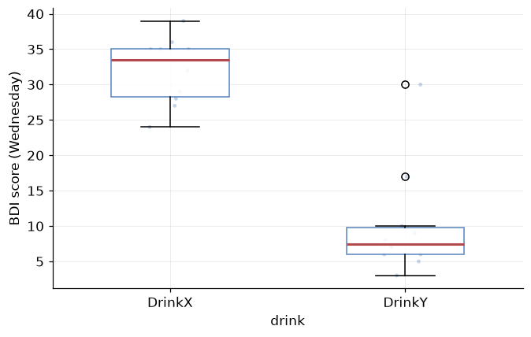

```python
m9.grouped_box(bdi, "bdiwed", "drink", ylabel="BDI score (Wednesday)");
```

### Step 3: Check the assumptions

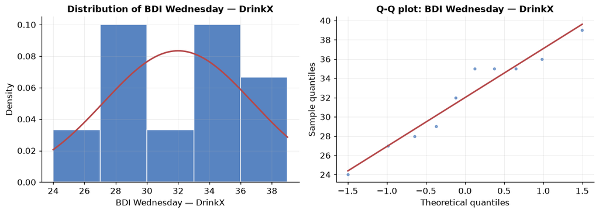

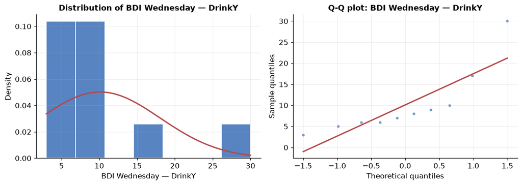

```python
for level in sorted(bdi.drink.unique()):
    m9.normality_panel(bdi.loc[bdi.drink == level, "bdiwed"], label=f"BDI Wednesday — {level}")
```

With ten observations per group there is very little to go on visually, and a formal normality test has almost no power. When the sample is this small and the outcome is a bounded questionnaire score, the safer choice is a test that does not assume normality.

### Steps 4–5: Run the test and get an effect size

The Mann–Whitney *U* test compares the **ranks** of the observations rather than their means.

```python
x = bdi.loc[bdi.drink == "DrinkX", "bdiwed"]
y = bdi.loc[bdi.drink == "DrinkY", "bdiwed"]

mw = stats.mannwhitneyu(x, y, alternative="two-sided")
mw
```

```
MannwhitneyuResult(statistic=np.float64(96.0), pvalue=np.float64(0.0005690342182204761))
```

Ties are common in questionnaire data. They are handled by a normal approximation with a tie correction — they are **not** missing data, and they do not invalidate the test.

```python
print(f"tied values present: {bdi.bdiwed.duplicated().any()}")
```

```
tied values present: True
```

Two different effect sizes are both conventionally written *r* for this test, so name whichever you report:

- **Rank-biserial correlation** — computed from *U* directly. Rescaling it as (*r* + 1)/2 gives the probability that a randomly chosen member of the first group scores above one from the second, which makes it easy to explain.
- **Rosenthal's *r*** = |*z*|/√*N* — the older convention, and still the one you will meet in much of the literature.

```python
print(f"rank-biserial r  = {m9.rank_biserial(x, y):.3f}")
print(f"Rosenthal's r    = {m9.wilcoxon_r(x, y):.3f}")
```

```
rank-biserial r  = 0.920
Rosenthal's r    = 0.779
```

They answer slightly different questions and do not agree numerically. Pick one, say which you used, and stay consistent across a report.

### Step 6: Report and conclude

```python
m9.report_mannwhitney(
    bdi, "bdiwed", "drink", mw,
    outcome_label="depression score on Wednesday",
    group_labels={"DrinkX": "those who drank Drink X",
                  "DrinkY": "those who drank Drink Y"},
)
```

A Mann-Whitney *U* test was conducted to compare depression score on Wednesday between those who drank Drink X (*Mdn* = 33.50, *IQR* = 6.75) and those who drank Drink Y (*Mdn* = 7.50, *IQR* = 3.75). There was a statistically significant difference, *U* = 96.0, *p* < .001, rank-biserial *r* = 0.92 (large). The test compares the whole distributions, so it supports a conclusion about which group tends to score higher rather than about the medians alone.

Now the same comparison on the Sunday measurement, where the picture differs:

```python
mw_sun = stats.mannwhitneyu(bdi.loc[bdi.drink == "DrinkX", "bdisun"],
                            bdi.loc[bdi.drink == "DrinkY", "bdisun"],
                            alternative="two-sided")

m9.report_mannwhitney(
    bdi, "bdisun", "drink", mw_sun,
    outcome_label="depression score on Sunday",
    group_labels={"DrinkX": "those who drank Drink X",
                  "DrinkY": "those who drank Drink Y"},
)
```

A Mann-Whitney *U* test was conducted to compare depression score on Sunday between those who drank Drink X (*Mdn* = 17.50, *IQR* = 3.75) and those who drank Drink Y (*Mdn* = 16.00, *IQR* = 3.00). There was no statistically significant difference, *U* = 64.5, *p* = .286, rank-biserial *r* = 0.29 (small). The test compares the whole distributions, so it supports a conclusion about which group tends to score higher rather than about the medians alone.

**Conclusion.** The drinks are indistinguishable the morning after, but differ three days later. Reporting both is what makes the finding meaningful.

## Part 3 — Two categorical variables

When *both* variables are categorical, we ask whether they are **associated**.

```python
bully = m9.load_bullying()
bully[["ubullsch", "ubulloth"]].head()
```

|  | ubullsch | ubulloth |
| --- | --- | --- |
| 0 | No | No |
| 1 | No | No |
| 2 | No | No |
| 3 | Yes | No |
| 4 | No | No |

### Step 1: State the hypothesis

> **H₀:** Being bullied at school and bullying others are independent.

> **H₁:** Being bullied at school and bullying others are associated.

### Step 2: Inspect

```python
m9.crosstab(bully, "ubullsch", "ubulloth")
```

| ubulloth ubullsch | No | Yes |
| --- | --- | --- |
| No | 530 | 25 |
| Yes | 209 | 35 |

Percentages within rows make the comparison readable — each row answers "of the people in this group, what proportion bullied others?"

```python
m9.crosstab(bully, "ubullsch", "ubulloth", normalize="index")
```

| ubulloth ubullsch | No | Yes |
| --- | --- | --- |
| No | 95.5 | 4.5 |
| Yes | 85.7 | 14.3 |

### Step 3: Check the assumptions

Chi-square relies on an approximation that needs reasonably large **expected** counts — conventionally, all above 5.

```python
table = m9.crosstab(bully.dropna(subset=["ubullsch", "ubulloth"]), "ubullsch", "ubulloth")
chi2, p, dof, expected = stats.chi2_contingency(table, correction=True)

import pandas as pd
pd.DataFrame(expected, index=table.index, columns=table.columns).round(1)
```

| ubulloth ubullsch | No | Yes |
| --- | --- | --- |
| No | 513.3 | 41.7 |
| Yes | 225.7 | 18.3 |

```python
print(f"smallest expected count: {expected.min():.1f}")
```

```
smallest expected count: 18.3
```

### Steps 4–6: Run, report, conclude

For a 2×2 table we apply Yates' continuity correction.

```python
m9.report_chisquare(
    table, (chi2, p, dof, expected),
    row_label="having been bullied at school",
    col_label="having bullied others",
)
```

A chi-square test of independence examined the association between having been bullied at school and having bullied others. There was a statistically significant association, χ²(1, *N* = 799) = 22.23, *p* < .001, Cramér's *V* = 0.172 (small).

For a 2×2 table Cramér's *V* is identical to the φ coefficient, which is what you will see reported in the textbooks for tables of this shape.

**Conclusion.** There is evidence of an association, and its size is small. Both halves of that sentence matter: with 799 respondents even a weak association will reach significance, so the effect size is what tells you whether it is practically important.

## Choosing between the tests

```python
m9.md("""
| Your outcome | Your groups | Use |
|---|---|---|
| Continuous, roughly normal within groups | 2 | Welch's *t*-test |
| Continuous but clearly skewed, or ordinal, or a very small sample | 2 | Mann–Whitney *U* |
| Categorical | Categorical | Chi-square of independence |
""")
```

| Your outcome | Your groups | Use |
| --- | --- | --- |
| Continuous, roughly normal within groups | 2 | Welch's *t*-test |
| Continuous but clearly skewed, or ordinal, or a very small sample | 2 | Mann–Whitney *U* |
| Categorical | Categorical | Chi-square of independence |

Two habits to carry forward:

- **Decide from the data, and say what you decided from.** "The Q-Q plot showed the residuals following the reference line closely" is evidence. "The data were normal" is not.
- **Never report a p-value on its own.** A significant result with a negligible effect size and a non-significant result with a moderate one are both common, and both are easy to misread without the effect size beside them.

## Exercise

`exercise.md` asks you to run all three tests on variables you have not seen yet, and to write the reports yourself.